In fact, there is a mathematical approach to finding the *best* way to add up the ballots, called “singular value decomposition” (SVD). The mathematics of SVD draw on a knowledge of matrix algebra, but the operation itself is readily available to anyone.[^4] The next plot shows the position of each member on the best two ways of summing up the ballots.

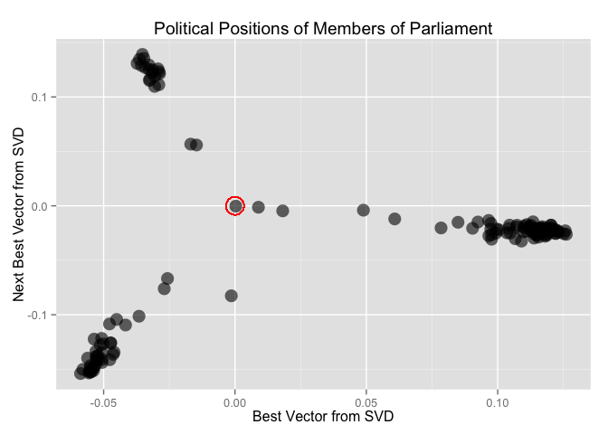

```r
Best <- data.frame( one=c(b1), two=c(b2), three=res$v[,3], four=res$v[,4], five=res$v[,5] )
clusts <- kmeans( Best, centers=5)
Best$cluster <- as.factor(clusts$cluster)
ggplot( data=Best, aes( x=one, y=two )) +
    geom_point( shape=1, color='red', size=7, aes(x=0,y=0)) +
  geom_point( size=5, alpha=.6 ) +
  xlab("Best Vector from SVD") +
  ylab("Next Best Vector from SVD") +
  ggtitle("Political Positions of Members of Parliament")
```

At a glance, you can see that there are three main clusters. The red circle marks the “average” member. The three clusters move away from average in different directions. There are several members whose position is in-between the average and the cluster to which they are closest.

Just as there are clusters of political positions, there are clusters of ballots that might correspond to such factors as social effect, economic effect, etc. Here’s a graphic showing the position of ballots, using the best two SVD sums.

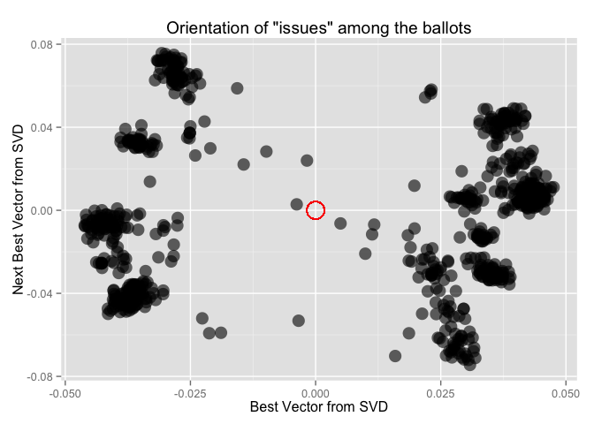

```r
BestBallots <- data.frame( one=res$u[,1], two=res$u[,2], three=res$u[,3], four=res$u[,4], five=res$u[,5] )
clustBallots <- kmeans( BestBallots, centers=16 )
BestBallots$cluster <- as.factor(clustBallots$cluster)
ggplot( data=BestBallots, aes( x=one, y=two )) +
    geom_point( shape=1, color='red', size=7, aes(x=0,y=0)) +
  geom_point( size=5, alpha=.6 ) +
  xlab("Best Vector from SVD") +
  ylab("Next Best Vector from SVD") +
  ggtitle('Orientation of \"issues\" among the ballots')
```

There are obvious clusters in this plot. Still, interpretation can be tricky. Remember that, on each issue, there are both yay and nay votes. This is what accounts for the symmetry of the dots around the center (indicated in red). The opposing dots along each angle from the center might be interpretted in terms of “socially liberal” vs “socially conservative”, “economically liberal” versus “economically” conservative. Deciding which is which likely involves reading the bill itself.

Finally, the “best” sums from SVD can be used to re-arrange cases and separately re-arrange variables while keeping exactly the same values for each case in each variable. This amounts simply to re-ordering the members in a way other than alphabetical and similarly with the ballots. This can simplify the appearance of the data.

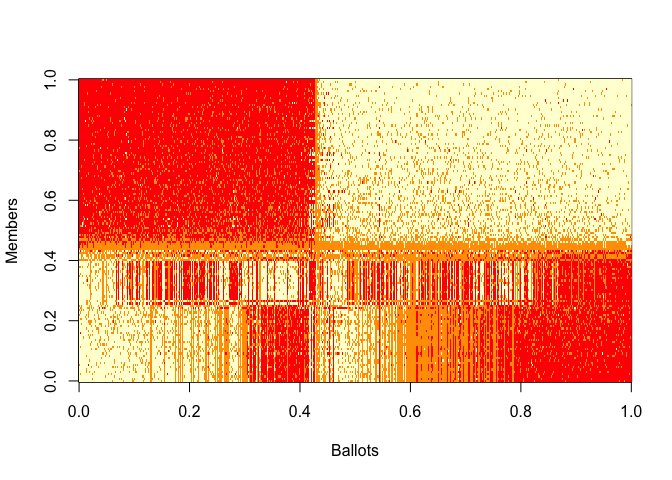

```r
inds1 <- order(c(res$u[,1]))
inds2 <- order(c(res$v[,1]))
VA <- VAlpha[ inds1, inds2 ]
image( VA, xlab="Ballots", ylab="Members")
```

Cases: e.g. NCI60

Variables: * hierarchical modeling typically uses only a few variables even when many are available. * SVD and the Scottish parliament.

## Working with Multiple (> 3) Variables

The most important methods are ones that will not be described here: regression methods.  
* Linear regression and a set of related regression techniques such as logistic regression.

Why not? Using them properly requires understanding some theory and several concepts: residual, colinearity, coefficients and multivariable polynomials, confidence interval, significance.  
* Explanatory vars and response *

## Ideas

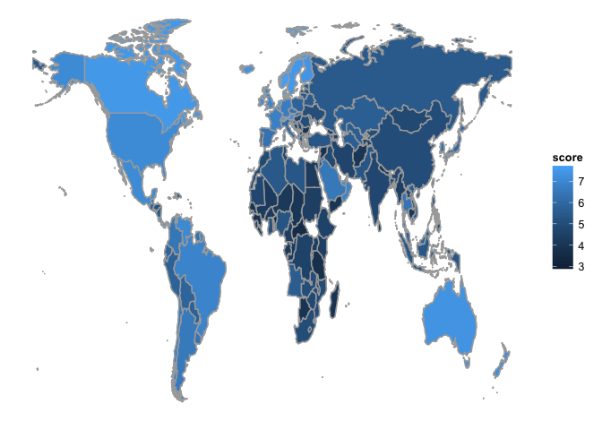

```r
mosaic::mWorldMap( HappinessIndex, key="country", fill="score")
```

These notes are about how to deal with data that has many variables.